# Python Code Public Examples

## Juan D. Correa - Software Developher @ Veracruz,MX & California,USA

# Juan David Correa (BATCH: MIT-DSML-NOVEMBER 2024-B)

# Course: "Classification and Hypothesis Testing".

# ExtraaLearn Project -- January, 2025

## Context

The EdTech industry has been surging in the past decade immensely, and according to a forecast, the Online Education market would be worth $286.62bn by 2023 with a compound annual growth rate (CAGR) of 10.26% from 2018 to 2023. The modern era of online education has enforced a lot in its growth and expansion beyond any limit. Due to having many dominant features like ease of information sharing, personalized learning experience, transparency of assessment, etc, it is now preferable to traditional education.

In the present scenario due to the Covid-19, the online education sector has witnessed rapid growth and is attracting a lot of new customers. Due to this rapid growth, many new companies have emerged in this industry. With the availability and ease of use of digital marketing resources, companies can reach out to a wider audience with their offerings. The customers who show interest in these offerings are termed as leads. There are various sources of obtaining leads for Edtech companies, like

- The customer interacts with the marketing front on social media or other online platforms.
- The customer browses the website/app and downloads the brochure
- The customer connects through emails for more information.

The company then nurtures these leads and tries to convert them to paid customers. For this, the representative from the organization connects with the lead on call or through email to share further details.

## Objective

ExtraaLearn is an initial stage startup that offers programs on cutting-edge technologies to students and professionals to help them upskill/reskill. With a large number of leads being generated on a regular basis, one of the issues faced by ExtraaLearn is to identify which of the leads are more likely to convert so that they can allocate resources accordingly. You, as a data scientist at ExtraaLearn, have been provided the leads data to:

- Analyze and build an ML model to help identify which leads are more likely to convert to paid customers,
- Find the factors driving the lead conversion process
- Create a profile of the leads which are likely to convert

## Data Description

The data contains the different attributes of leads and their interaction details with ExtraaLearn. The detailed data dictionary is given below.

**Data Dictionary**

- ID: ID of the lead
- age: Age of the lead
- current_occupation: Current occupation of the lead. Values include 'Professional','Unemployed',and 'Student'
- first_interaction: How did the lead first interacted with ExtraaLearn. Values include 'Website', 'Mobile App'
- profile_completed: What percentage of profile has been filled by the lead on the website/mobile app. Values include Low - (0-50%), Medium - (50-75%), High (75-100%)
- website_visits: How many times has a lead visited the website
- time_spent_on_website: Total time spent on the website
- page_views_per_visit: Average number of pages on the website viewed during the visits.
- last_activity: Last interaction between the lead and ExtraaLearn.
  - Email Activity: Seeking for details about program through email, Representative shared information with lead like brochure of program , etc
  - Phone Activity: Had a Phone Conversation with representative, Had conversation over SMS with representative, etc
  - Website Activity: Interacted on live chat with representative, Updated profile on website, etc
- print_media_type1: Flag indicating whether the lead had seen the ad of ExtraaLearn in the Newspaper.
- print_media_type2: Flag indicating whether the lead had seen the ad of ExtraaLearn in the Magazine.
- digital_media: Flag indicating whether the lead had seen the ad of ExtraaLearn on the digital platforms.
- educational_channels: Flag indicating whether the lead had heard about ExtraaLearn in the education channels like online forums, discussion threads, educational websites, etc.
- referral: Flag indicating whether the lead had heard about ExtraaLearn through reference.
- status: Flag indicating whether the lead was converted to a paid customer or not.

=======================================================================================================================================

# Homework Description:

The goal of this notebook is to analyze the dataset, train machine learning models, and evaluate their performance to predict program enrollment (`status`).

We explored the dataset, applied PCA for dimensionality reduction, and built classification models such as Decision Tree and Random Forest.

Bonus Analysis: As a bonus, we performed clustering (using DBSCAN) to refine our understanding of the dataset. Clustering helped uncover behavioral patterns and subgroups among users, complementing the supervised models. This deeper exploration provided additional insights into engagement metrics and user behavior, which can guide strategies to increase program enrollment.

## Importing necessary libraries and data

```python
# Importing the basic libraries we will require for the project

# Libraries to help with reading and manipulating data
import pandas as pd
import numpy as np

# Libaries to help with data visualization
import matplotlib.pyplot as plt
import seaborn as sns
sns.set()

# Importing the Machine Learning models we require from Scikit-Learn
from sklearn.linear_model import LogisticRegression
from sklearn.svm import SVC
from sklearn.tree import DecisionTreeClassifier
from sklearn import tree
from sklearn.ensemble import RandomForestClassifier
from sklearn.cluster import KMeans
from sklearn.metrics import silhouette_score

# Importing the other functions we may require from Scikit-Learn
from sklearn.model_selection import train_test_split, GridSearchCV
from sklearn.preprocessing import MinMaxScaler, OneHotEncoder
from sklearn.impute import SimpleImputer

# To get diferent metric scores
from sklearn.metrics import confusion_matrix,classification_report,roc_auc_score,precision_recall_curve,roc_curve,make_scorer
from sklearn.metrics import accuracy_score, classification_report
from sklearn.metrics import adjusted_rand_score, adjusted_mutual_info_score

from sklearn.tree import plot_tree

from sklearn.preprocessing import LabelEncoder, StandardScaler
from sklearn.decomposition import PCA
from sklearn.compose import ColumnTransformer
from sklearn.pipeline import Pipeline


from sklearn.cluster import DBSCAN
from xgboost import XGBClassifier


# Code to ignore warnings from function usage
import warnings;

warnings.filterwarnings('ignore')
```

# Dataset Exploration:

Imported the dataset and explored its structure using: .head(), .tail(), .shape, .info(). Analyzed missing values and unique values for each column. Dropped unnecessary columns (e.g., ID) to clean the dataset. Feature Engineering and Preprocessing:

Converted categorical columns to the category data type. Checked for consistency in the dataset after cleaning. Dimensionality Reduction (PCA):

Applied PCA to reduce dimensionality while retaining key patterns in the data. Visualized the explained variance ratio for each PCA component to select the most impactful features. Model Training and Evaluation:

Decision Tree: Built a Decision Tree model and optimized it using hyperparameters like max_depth. Evaluated the model with metrics such as accuracy, precision, recall, and F1-score.

Random Forest: Trained a Random Forest model for better generalization and stability. Compared performance against the Decision Tree, noting improved accuracy and balance in class metrics. Insights from Tree-Based Models:

```python
file_path = 'ExtraaLearn.csv'
data= pd.read_csv(file_path)
```

## Exploratory Data Analysis (EDA)

- EDA is an important part of any project involving data.
- It is important to investigate and understand the data better before building a model with it.
- A few questions have been mentioned below which will help you approach the analysis in the right manner and generate insights from the data.
- A thorough analysis of the data, in addition to the questions mentioned below, should be done.

```python
data.head()
```

|  | ID | age | current_occupation | first_interaction | profile_completed | website_visits | time_spent_on_website | page_views_per_visit | last_activity | print_media_type1 | print_media_type2 | digital_media | educational_channels | referral | status |
| --- | --- | --- | --- | --- | --- | --- | --- | --- | --- | --- | --- | --- | --- | --- | --- |
| 0 | EXT001 | 57 | Unemployed | Website | High | 7 | 1639 | 1.861 | Website Activity | Yes | No | Yes | No | No | 1 |
| 1 | EXT002 | 56 | Professional | Mobile App | Medium | 2 | 83 | 0.320 | Website Activity | No | No | No | Yes | No | 0 |
| 2 | EXT003 | 52 | Professional | Website | Medium | 3 | 330 | 0.074 | Website Activity | No | No | Yes | No | No | 0 |
| 3 | EXT004 | 53 | Unemployed | Website | High | 4 | 464 | 2.057 | Website Activity | No | No | No | No | No | 1 |
| 4 | EXT005 | 23 | Student | Website | High | 4 | 600 | 16.914 | Email Activity | No | No | No | No | No | 0 |

```python
data.tail()
```

|  | ID | age | current_occupation | first_interaction | profile_completed | website_visits | time_spent_on_website | page_views_per_visit | last_activity | print_media_type1 | print_media_type2 | digital_media | educational_channels | referral | status |
| --- | --- | --- | --- | --- | --- | --- | --- | --- | --- | --- | --- | --- | --- | --- | --- |
| 4607 | EXT4608 | 35 | Unemployed | Mobile App | Medium | 15 | 360 | 2.170 | Phone Activity | No | No | No | Yes | No | 0 |
| 4608 | EXT4609 | 55 | Professional | Mobile App | Medium | 8 | 2327 | 5.393 | Email Activity | No | No | No | No | No | 0 |
| 4609 | EXT4610 | 58 | Professional | Website | High | 2 | 212 | 2.692 | Email Activity | No | No | No | No | No | 1 |
| 4610 | EXT4611 | 57 | Professional | Mobile App | Medium | 1 | 154 | 3.879 | Website Activity | Yes | No | No | No | No | 0 |
| 4611 | EXT4612 | 55 | Professional | Website | Medium | 4 | 2290 | 2.075 | Phone Activity | No | No | No | No | No | 0 |

```python
data.shape
```

```
(4612, 15)
```

```python
data.info()
```

```
<class 'pandas.core.frame.DataFrame'>
RangeIndex: 4612 entries, 0 to 4611
Data columns (total 15 columns):
 #   Column                 Non-Null Count  Dtype
---  ------                 --------------  -----
 0   ID                     4612 non-null   object
 1   age                    4612 non-null   int64
 2   current_occupation     4612 non-null   object
 3   first_interaction      4612 non-null   object
 4   profile_completed      4612 non-null   object
 5   website_visits         4612 non-null   int64
 6   time_spent_on_website  4612 non-null   int64
 7   page_views_per_visit   4612 non-null   float64
 8   last_activity          4612 non-null   object
 9   print_media_type1      4612 non-null   object
 10  print_media_type2      4612 non-null   object
 11  digital_media          4612 non-null   object
 12  educational_channels   4612 non-null   object
 13  referral               4612 non-null   object
 14  status                 4612 non-null   int64
dtypes: float64(1), int64(4), object(10)
memory usage: 540.6+ KB
```

```python
# change page_views_per_visit from float64 to int64
data['page_views_per_visit'] = data['page_views_per_visit'].astype('int64')
```

```python
pd.DataFrame(data={'% of Missing Values':round(data.isna().sum()/data.isna().count()*100,2)}).sort_values(by='% of Missing Values',ascending=False)
```

|  | % of Missing Values |
| --- | --- |
| ID | 0.0 |
| age | 0.0 |
| current_occupation | 0.0 |
| first_interaction | 0.0 |
| profile_completed | 0.0 |
| website_visits | 0.0 |
| time_spent_on_website | 0.0 |
| page_views_per_visit | 0.0 |
| last_activity | 0.0 |
| print_media_type1 | 0.0 |
| print_media_type2 | 0.0 |
| digital_media | 0.0 |
| educational_channels | 0.0 |
| referral | 0.0 |
| status | 0.0 |

```python
data.nunique()
```

```
ID                       4612
age                        46
current_occupation          3
first_interaction           2
profile_completed           3
website_visits             27
time_spent_on_website    1623
page_views_per_visit       17
last_activity               3
print_media_type1           2
print_media_type2           2
digital_media               2
educational_channels        2
referral                    2
status                      2
dtype: int64
```

```python
data.drop(columns='ID',inplace=True)
```

```python
data.describe().T
```

|  | count | mean | std | min | 25% | 50% | 75% | max |
| --- | --- | --- | --- | --- | --- | --- | --- | --- |
| age | 4612.0 | 46.201214 | 13.161454 | 18.0 | 36.00 | 51.0 | 57.00 | 63.0 |
| website_visits | 4612.0 | 3.566782 | 2.829134 | 0.0 | 2.00 | 3.0 | 5.00 | 30.0 |
| time_spent_on_website | 4612.0 | 724.011275 | 743.828683 | 0.0 | 148.75 | 376.0 | 1336.75 | 2537.0 |
| page_views_per_visit | 4612.0 | 2.641804 | 1.879720 | 0.0 | 2.00 | 2.0 | 3.00 | 18.0 |
| status | 4612.0 | 0.298569 | 0.457680 | 0.0 | 0.00 | 0.0 | 1.00 | 1.0 |

```python
# Frequency tables for categorical columns
categorical_columns = data.select_dtypes(include=['object', 'category']).columns
for col in categorical_columns:
    print(f"Frequency table for {col}:\n")
    print(data[col].value_counts())
    print("\n")
```

```
Frequency table for current_occupation:

current_occupation
Professional    2616
Unemployed      1441
Student          555
Name: count, dtype: int64


Frequency table for first_interaction:

first_interaction
Website       2542
Mobile App    2070
Name: count, dtype: int64


Frequency table for profile_completed:

profile_completed
High      2264
Medium    2241
Low        107
Name: count, dtype: int64


Frequency table for last_activity:

last_activity
Email Activity      2278
Phone Activity      1234
Website Activity    1100
Name: count, dtype: int64


Frequency table for print_media_type1:

print_media_type1
No     4115
Yes     497
```

[output cut: 18 more lines]

```

Frequency table for educational_channels:

educational_channels
No     3907
Yes     705
Name: count, dtype: int64


Frequency table for referral:

referral
No     4519
Yes      93
Name: count, dtype: int64
```

```python
# Identify categorical and numeric columns
cat_cols = data.select_dtypes(include=['object', 'category']).columns
numeric_cols = data.select_dtypes(include=['number']).columns

print(f"Categorical columns: {cat_cols}")
print(f"Numeric columns: {numeric_cols}")
```

```
Categorical columns: Index(['current_occupation', 'first_interaction', 'profile_completed',
       'last_activity', 'print_media_type1', 'print_media_type2',
       'digital_media', 'educational_channels', 'referral'],
      dtype='object')
Numeric columns: Index(['age', 'website_visits', 'time_spent_on_website',
       'page_views_per_visit', 'status'],
      dtype='object')
```

```python
data.info()
```

```
<class 'pandas.core.frame.DataFrame'>
RangeIndex: 4612 entries, 0 to 4611
Data columns (total 14 columns):
 #   Column                 Non-Null Count  Dtype
---  ------                 --------------  -----
 0   age                    4612 non-null   int64
 1   current_occupation     4612 non-null   object
 2   first_interaction      4612 non-null   object
 3   profile_completed      4612 non-null   object
 4   website_visits         4612 non-null   int64
 5   time_spent_on_website  4612 non-null   int64
 6   page_views_per_visit   4612 non-null   int64
 7   last_activity          4612 non-null   object
 8   print_media_type1      4612 non-null   object
 9   print_media_type2      4612 non-null   object
 10  digital_media          4612 non-null   object
 11  educational_channels   4612 non-null   object
 12  referral               4612 non-null   object
 13  status                 4612 non-null   int64
dtypes: int64(5), object(9)
memory usage: 504.6+ KB
```

```python
df = data.copy()
```

```python
df.head()
```

|  | age | current_occupation | first_interaction | profile_completed | website_visits | time_spent_on_website | page_views_per_visit | last_activity | print_media_type1 | print_media_type2 | digital_media | educational_channels | referral | status |
| --- | --- | --- | --- | --- | --- | --- | --- | --- | --- | --- | --- | --- | --- | --- |
| 0 | 57 | Unemployed | Website | High | 7 | 1639 | 1 | Website Activity | Yes | No | Yes | No | No | 1 |
| 1 | 56 | Professional | Mobile App | Medium | 2 | 83 | 0 | Website Activity | No | No | No | Yes | No | 0 |
| 2 | 52 | Professional | Website | Medium | 3 | 330 | 0 | Website Activity | No | No | Yes | No | No | 0 |
| 3 | 53 | Unemployed | Website | High | 4 | 464 | 2 | Website Activity | No | No | No | No | No | 1 |
| 4 | 23 | Student | Website | High | 4 | 600 | 16 | Email Activity | No | No | No | No | No | 0 |

# Univariate Analysis

```python
# Defining the hist_box() function
def hist_box(data, col):
    f, (ax_box, ax_hist) = plt.subplots(2, sharex=True, gridspec_kw={'height_ratios': (0.15, 0.85)}, figsize=(10, 10))
    # Adding a graph in each part
    sns.boxplot(data=data, x=col, ax=ax_box, showmeans=True)
    sns.histplot(data=data, x=col, kde=True, ax=ax_hist)
    plt.show()
```

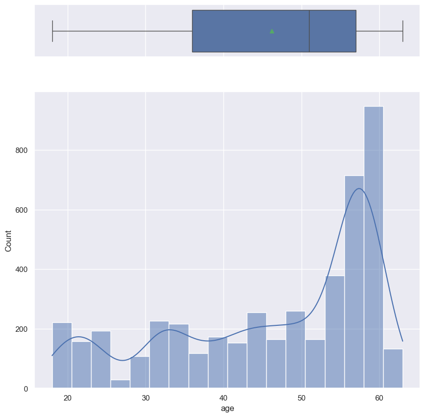

```python
hist_box(df, "age")
```

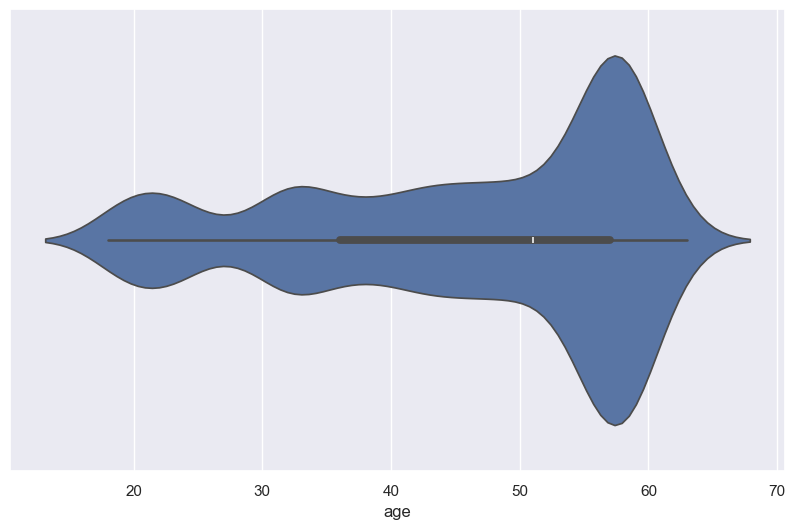

```python
plt.figure(figsize=(10, 6))
sns.violinplot(x = df['age'])
plt.show()
```

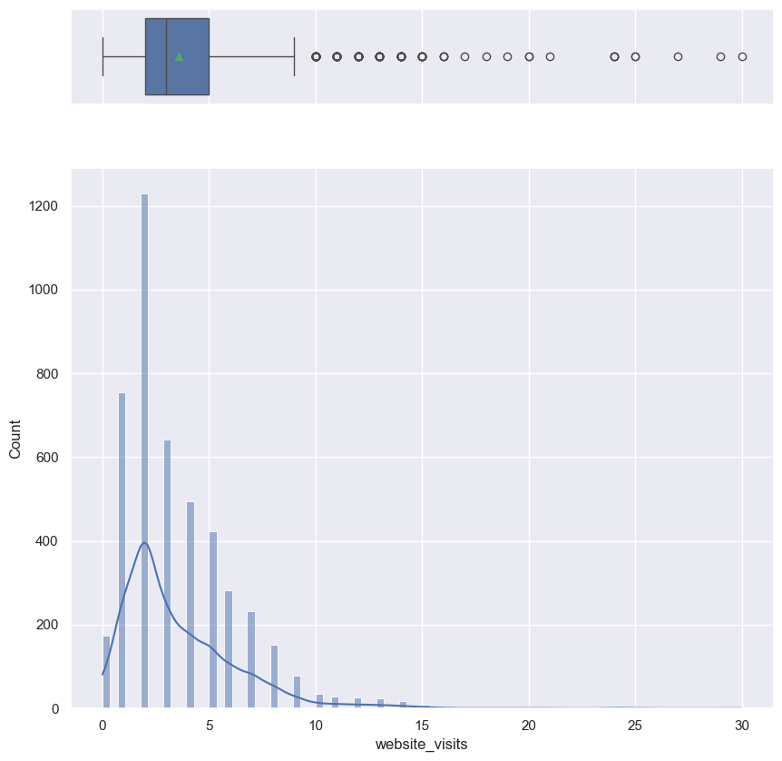

```python
hist_box(df, 'website_visits')
```

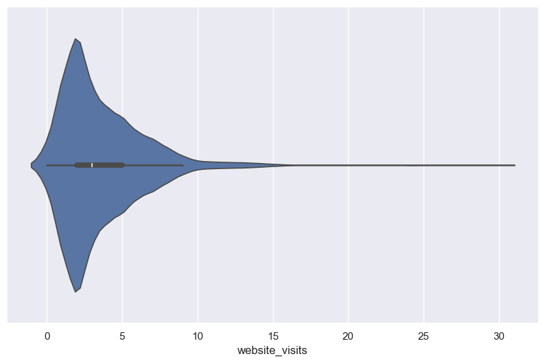

```python
plt.figure(figsize=(10, 6))
sns.violinplot(x = df['website_visits'])
plt.show()
```

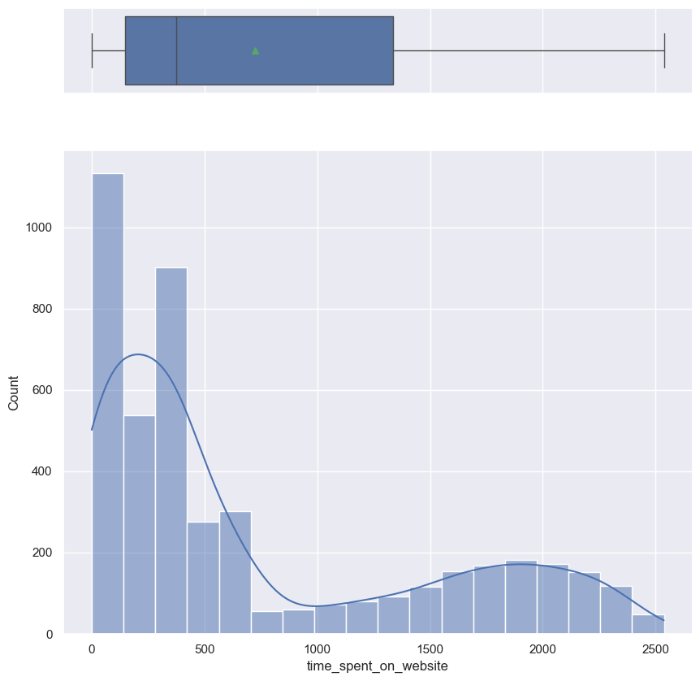

```python
hist_box(df, 'time_spent_on_website')
```

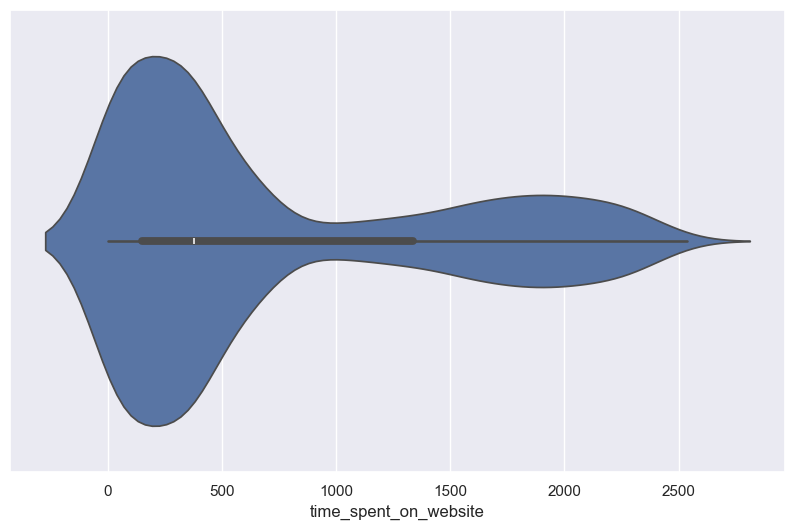

```python
plt.figure(figsize=(10, 6))
sns.violinplot(x = df['time_spent_on_website'])
plt.show()
```

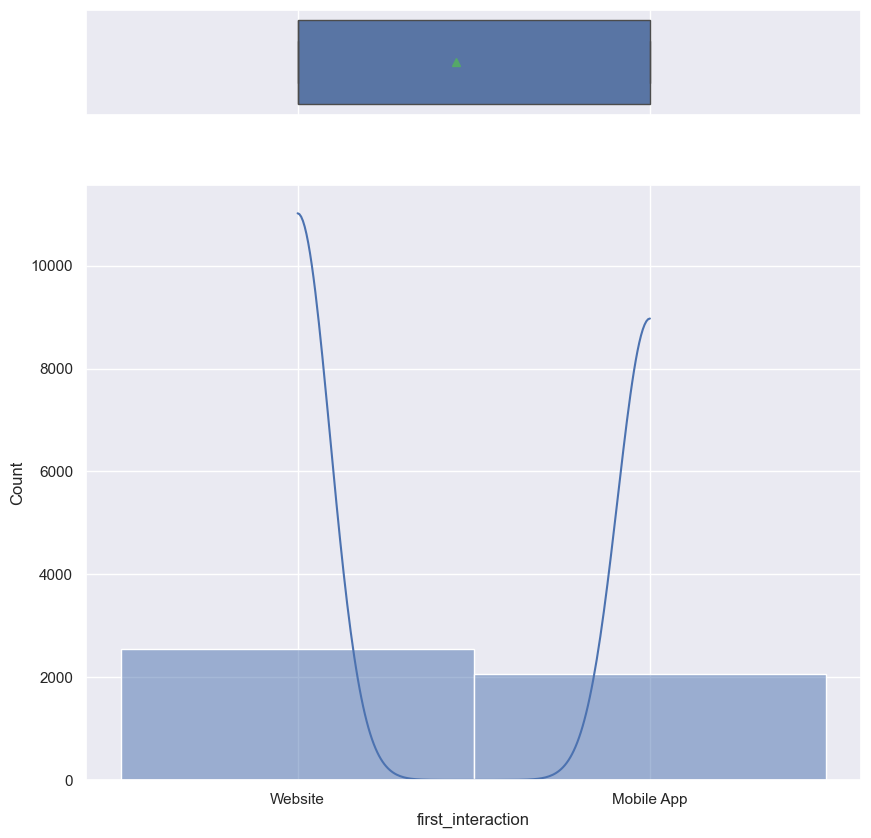

```python
hist_box(df,'first_interaction')
```

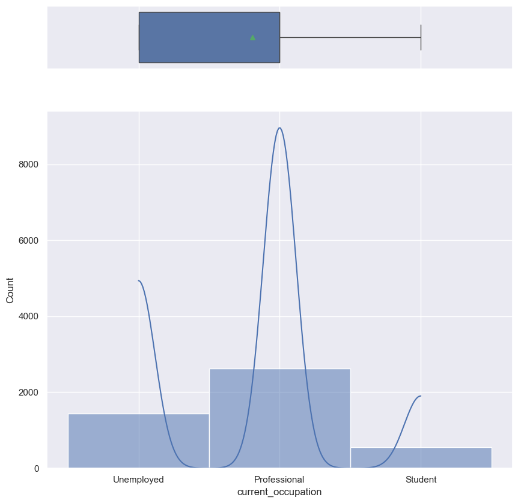

```python
hist_box(df, 'current_occupation')
```

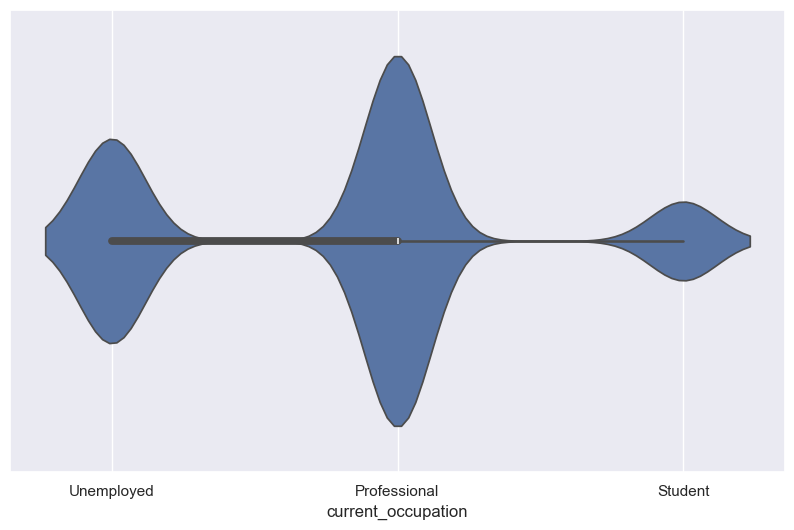

```python
plt.figure(figsize=(10, 6))
sns.violinplot(x = df['current_occupation'])
plt.show()
```

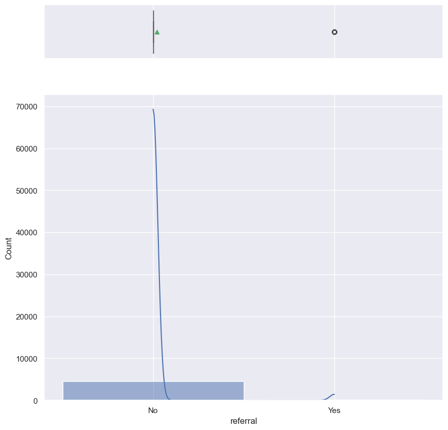

```python
hist_box(df, 'referral')
```

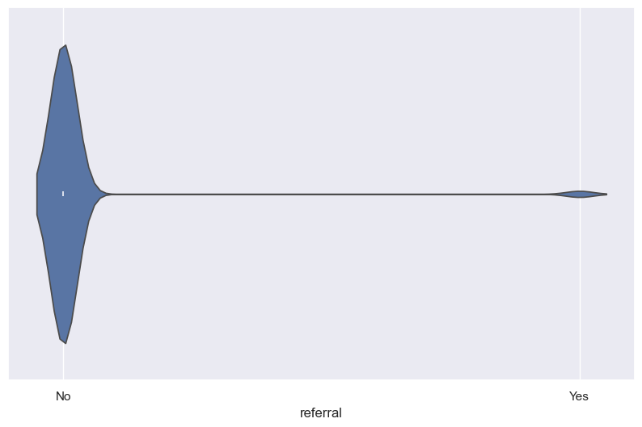

```python
plt.figure(figsize=(10, 6))
sns.violinplot(x = df['referral'])
plt.show()
```

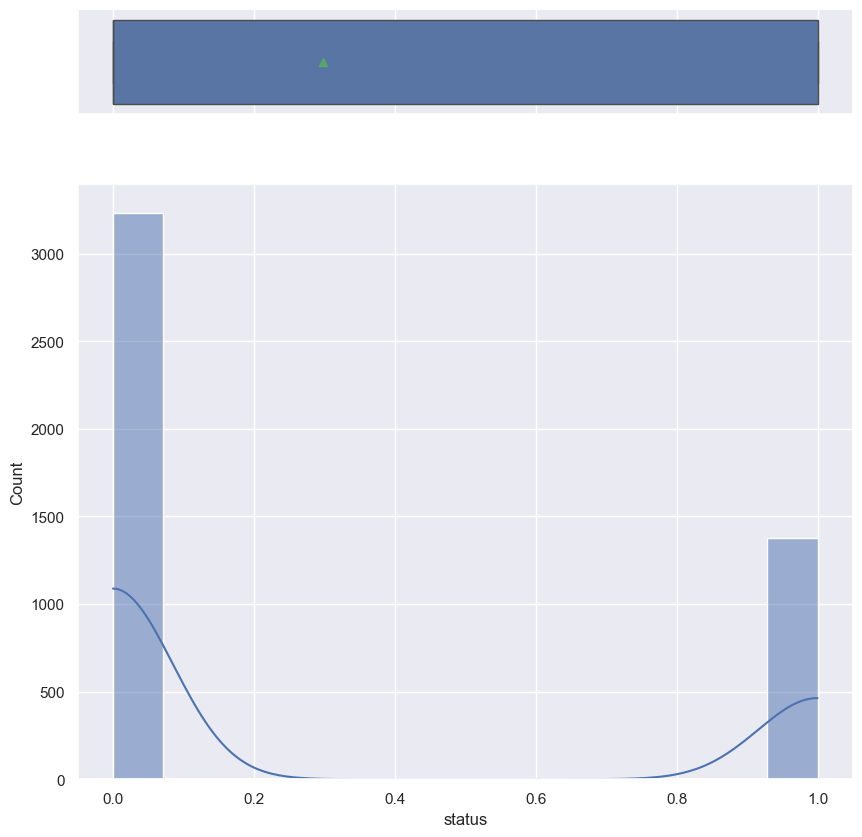

```python
hist_box(df, 'status')
```

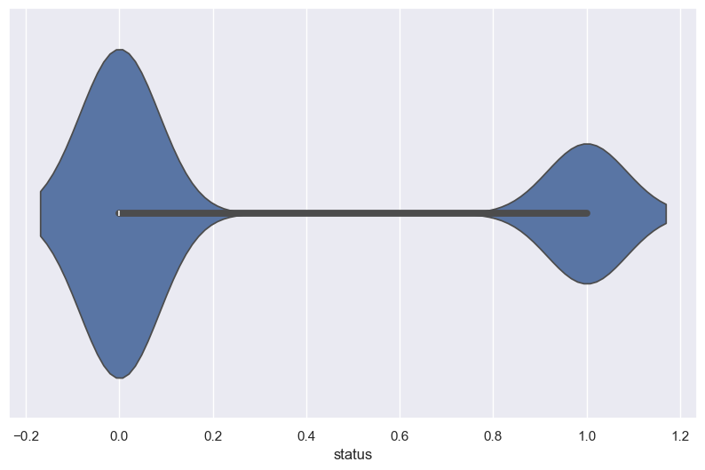

```python
plt.figure(figsize=(10, 6))
sns.violinplot(x = df['status'])
plt.show()
```

# Bivariate Anaysis

```python
# Defining the stacked_barplot() function
def stacked_barplot(data,predictor,target,figsize=(10,6)):
  (pd.crosstab(data[predictor],data[target],normalize='index')*100).plot(kind='bar',figsize=figsize,stacked=True)
  plt.legend(loc="lower right")
  plt.ylabel(target)
```

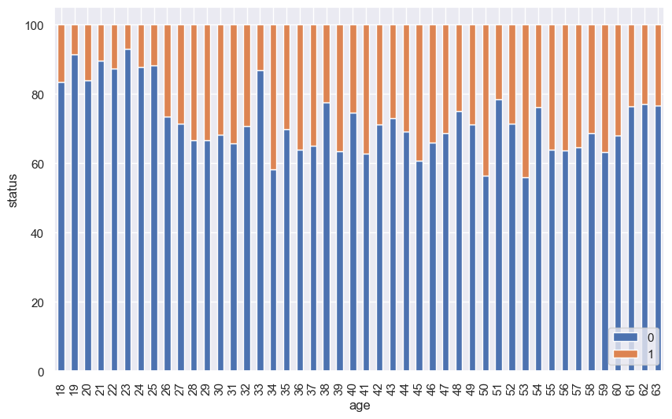

```python
plt.figure(figsize=(100, 6))
stacked_barplot(data, "age", "status" )
```

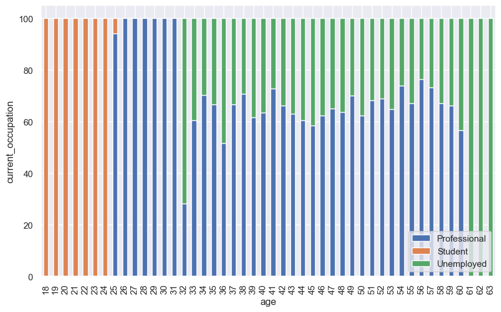

```python
stacked_barplot(data, "age", "current_occupation" )
```

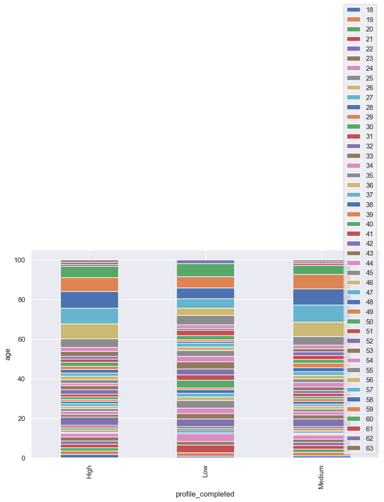

```python
plt.figure(figsize=(70, 6))
stacked_barplot(data, "profile_completed", "age" )
```